# ChIPseq practical

## Resources used

[Bowtie2](http://bowtie-bio.sourceforge.net/bowtie2/index.shtml)

[Samtools](http://samtools.sourceforge.net/)

[Bedtools](http://bedtools.readthedocs.io/en/latest/)

[IGV genome browser](http://www.broadinstitute.org/igv/)

[MACS2](https://github.com/taoliu/MACS)

[ChIPseeker](https://www.bioconductor.org/packages/devel/bioc/vignettes/ChIPseeker/inst/doc/ChIPseeker.html)

[MEME](http://meme.sdsc.edu/meme/cgi-bin/meme.cgi)

[TOMTOM](http://meme.sdsc.edu/meme/cgi-bin/tomtom.cgi)

[DeepTools](http://deeptools.readthedocs.io/en/latest/index.html)

## Additional resources:

[Ensembl](http://www.ensembl.org)

[Original Data](http://www.ebi.ac.uk/ena/data/view/PRJNA242533)

These data are reported in Buecker, C. et al. Reorganization of Enhancer Patterns in Transition from Naive to Primed Pluripotency. Cell Stem Cell 14, 838–853 (2014).

# Introduction

The goal of this hands-on session is to perform some basic tasks in the analysis of ChIP-seq data. The first step includes an short read alignment for a small subset of raw reads. We will align raw sequencing data to the mouse genome using Bowtie2 and then we will manipulate the SAM output in order to visualise the alignment on the *IGV* browser. Then based on these aligned reads we will find enriched regions using the peak caller *MACS*. We will then perform functional annotation and motif analysis on the predicted binding regions.

# Prepare the environment

We will use one data set in this practical, which can be found in the ChIP-seq directory on your desktop. Throughout this practical we will try to identify potential transcription factor binding sites of Oct4 in mouse embryonic stem cells.

Open the Terminal.

First, go to the right folder, where the data are stored.

```bash
cd ~/Course_Materials/Practicals/ChIPseq
```

The .fastq file that we will align is called Oct4.fastq. This file is based on Oct4 ChIP-seq data published by Buecker et al. (2014). We will align these reads to the mouse chromosome 1.

# Alignment

There are a number of competing tools for short read alignment, each with its own set of strengths, weaknesses, and caveats. Here we will try *Bowtie2*, a widely used ultrafast, memory efficient short read aligner.

*Bowtie2* has a number of parameters in order to perform the alignment.

To view them all type

```
bowtie2
```

Bowtie2 uses indexed genome for the alignment in order to keep its memory footprint small. Because of time constraints we will build the index only for one chromosome of the mouse genome. For this we need the chromosome sequence in fasta format. This is stored in a file named mm10, under the subdirectory `bowtie_index`.

The indexed chromosome is generated using the following command:

```
bowtie2-build bowtie_index/mm10.fa.gz bowtie_index/mm10
```

This command will output 6 files that constitute the index. These files that have the prefix mm10 are stored in the bowtie_index subdirectory.

To view if these files have been successfully created type:

```
ls -l bowtie_index
```

Now that the genome is indexed we can move on to the actual alignment. Align the Oct4 reads using *Bowtie2*:

```
bowtie2 -p 6 -x bowtie_index/mm10 -U fastq/Oct4.fastq.gz -S Oct4.sam
```

Note: while the command is running there is no indication in the terminal that anything is happening. You can use the command `htop` in another terminal window to check activity on the computer.

The above command outputs the alignment in SAM format and stores them in the file `Oct4.sam`.

In general before you run *Bowtie*, you have to know which fastq format you have. The available fastq formats in bowtie are:

The fastq files we are working on is of Sanger format (Phred+33), which is the default for *Bowtie2*.

*Bowtie2* will take 2-3 minutes to align the file. This is fast compared to other aligners that sacrifice some speed to obtain higher sensitivity.

Look at the SAM format by typing:

```
head -n 10 Oct4.sam
```

Look at https://samtools.github.io/hts-specs/SAMv1.pdf to get more imformation about SAM format.

The second field in each alignment record is the “SAM flag”. This provides information about the read read alignment, e.g if the read is paired. The following website provides a simple means of interpreting these flags:

https://broadinstitute.github.io/picard/explain-flags.html

## Questions

1. Can you distinguish between the header of the SAM format and the actual alignments?
2. What kind of information does the header provide you with?
3. To which chromosome are the reads mapped?
4. To which strand is the first read mapped (use the flag)?

# Manipulate SAM output

SAM files are rather big and when dealing with a high volume of NGS data, storage space can become an issue. We can convert SAM to BAM files (their binary equivalent files that are not human readable) that occupy much less space.

Convert SAM to BAM using samtools and store the output in the file `Oct4.bam`. You have to instruct samtools that the input is in SAM format (`-S`), the output should be in BAM format (`-b`) and that you want the output to be stored in the file specified by the `-o` option:

```
samtools view -bSo Oct4.bam Oct4.sam
```

# Visualise alignments in IGV

It is often instructive to look at your data in a genome browser. Here, we use IGV, a stand-alone browser, which has the advantage of being installed locally and providing fast access. Web-based genome browsers, like Ensembl or the UCSC browser, are slower, but provide more functionality. They do not only allow for more polished and flexible visualisation, but also provide easy access to a wealth of annotations and external data sources. This makes it straightforward to relate your data with information about repeat regions, known genes, epigenetic features or areas of cross-species conservation, to name just a few. As such, they are useful tools for exploratory analysis.

Visualisation will allow you to get a ‘feel’ for the data, as well as detecting abnormalities and problems. Also, exploring the data in such a way may give you ideas for further analyses.

IGV is a stand-alone genome browser. Please check their website http://www.broadinstitute.org/igv/ for all the formats that IGV can display. For our visualisation purposes we will use the BAM and bigWig formats.

When uploading a BAM file into the genome browser, the browser will look for the index of the BAM file in the same folder where the BAM files is. The index file should have the same name as the BAM file and the suffix `.bai`. Finally, to create the index of a BAM file you need to make sure that the file is sorted according to chromosomal coordinates.

Sort alignments according to chromosome position and store the result in the file called `Oct4.sorted.bam`:

```
samtools sort -o Oct4.sorted.bam Oct4.bam
```

Index the sorted file.

```
samtools index Oct4.sorted.bam
```

The indexing will create a file called `Oct4.sorted.bam.bai`. Note that you do not have to specify the name of the index file when running samtools.

Another way to visualize the alignments is to convert the BAM file into a bigWig file. The bigWig format is for display of dense, continuous data and the data will be displayed as a graph. The resulting bigWig files are in an indexed binary format.

We can convert the bam to a bigwig file using `bamCoverage` from DeepTools. By default DeepTools summarises the coverage over 50 base windows, this has the advantage of making the output file much smaller, however, we can get base level resolution by setting the bin size to 1. We can also take advantage of multiple processors to speed the process up.

```
bamCoverage --bam Oct4.sorted.bam --outFileName Oct4.bw --binSize 1 -p 6
```

Now we will load the data into the IGV browser for visualization. In order to launch IGV type the following on your terminal:

```
igv &
```

On the top left of your screen choose from the drop down menu **Mus musculus (mm10)**. Then in order to load the desire files go to:

**File –> Load from File**

On the pop up window navigate to **Desktop > ChIP-seq** folder and select the file `Oct4.sorted.bam`.

Repeat these steps in order to load `Oct4.bw` as well.

Adjust the display as follows:

1. Select chr1 from the drop down menu on the top left.
2. Right click on the name of Oct4.bw and choose Maximum under the Windowing Function.
3. Right click again and select Autoscale.

In order to see the aligned reads of the BAM file, you need to zoom in to a specific region.

# Alignment of control .fastq file

In the `fastq` folder you will find another .fastq file called `Input.fastq.gz`. Repeat the steps described above for this dataset in order to align the control reads to the mouse genome as well. The final file should be called “Input.sorted.bam”.

**This step is essential to be able to perform the rest of the analyses.**

# Finding enriched areas using MACS

MACS stands for Model based analysis of ChIP-seq. It was designed for identifying transcription factor binding sites. MACS captures the influence of genome complexity to evaluate the significance of enriched ChIP regions, and improves the spatial resolution of binding sites through combining the information of both sequencing tag position and orientation. MACS can be easily used for ChIP-Seq data alone, or with a control sample to increase specificity.

Consult the MACS help file to see the options and parameters.

```
macs2 --help
macs2 callpeak --help
```

The input for MACS can be in ELAND, BED, SAM, BAM or BOWTIE formats (you just have to set the –format flag). Options that you will have to use include:

- `-t` to indicate the input ChIP file
- `-c` to indicate the name of the control file
- `--format` the tag file format. If this option is not set MACS automatically detects which format the file is.
- `--name` to set the name of the output files
- `--gsize` This is the mappable genome size. With the read length we have, 70% of the genome is a fair estimation. Since in this analysis we include only reads from chromosome 1, we will use as gsize 70% of the length of chromosome 1 (197 Mb). MACS also offers shortcuts for human, ‘mm’ for mouse ‘ce’ for *C. elegans* and ‘dm’ for fruitfly.
- `--call-summits` when this option is set MACS detects all subpeaks in each  
  enriched region and returns their summits
- `--pvalue` the P-value cutoff for peak detection.

Now run macs using the following command:

```
macs2 callpeak -t Oct4.bam  -c Input.bam --format BAM --name Oct4 \
    --gsize 138000000 --pvalue 1e-3 --call-summits
```

Open the Excel peak file and view the peak details. Note that the number of tags (column 6 `pileup`) refers to the number of reads at the summit ( i.e. summit height).

MACS generates its peak files in a file format called .narrowPeak file. This is a simple text format containing genomic locations, specified by chromosome, begin and end positions, and information on the statistical significance of each called peak. Details of the narrowPeak format can be found [here](http://genome.ucsc.edu/FAQ/FAQformat.html#format12).

NarrowPeak files can also be uploaded to IGV or other genome browsers.

Try uploading the peak file generated by MACS to IGV. Find the first peak in the file (use the head command to view the beginning of the `.narrowPeak` file).

## Questions

1. Is the first peak that was called convincing to you?
2. Compare the Oct4 peak profile with that of H3K4me3 histone modification. To do so, upload the `H3K4me3.bw` file, which is located within the ChIP-seq folder.
3. In IGV jump to location 1:35,987,885-36,101,395 for a sample peak. Do you think H3K4me3 peaks regions contain one or more modification sites? What about the Oct4 peak located within the Lemd1 gene?

# Annotation: From peaks to biological interpretation

In order to biologically interpret the results of ChIP-seq experiments, it is usually recommended to look at the genes and other annotated elements that are located in proximity to the identified enriched regions. We will use R package ChIPseeker (https://www.bioconductor.org/packages/devel/bioc/vignettes/ChIPseeker/inst/doc/ChIPseeker.html). We need to modify the peak files into BED format, which is a tab-delimited file that contains information on chromosome, start and end position for each region. See http://genome.ucsc.edu/FAQ/FAQformat.html#format1 for details.

To convert `Oct4_peaks.narrowPeak` to a BED file, type:

```
cut -f 1-4 Oct4_peaks.narrowPeak > Oct4_peaks.bed
```

Consult cut help file to see the options and parameters.

```
cut --help
```

Then start R in Terminal

```
R
```

```
#Load requied R libraries
library(tidyverse)
library(ChIPseeker)
library(TxDb.Mmusculus.UCSC.mm10.ensGene)
library(clusterProfiler)
library(org.Mm.eg.db)

txdb <- TxDb.Mmusculus.UCSC.mm10.ensGene

#Read bed file
peak <- readPeakFile("Oct4_peaks.bed")

#change chromosome annotation
seqlevelsStyle(peak) <- "UCSC"
peakAnno <- annotatePeak(peak, tssRegion=c(-3000, 3000), TxDb=txdb)

#Peak localisation plot
plotAnnoPie(peakAnno)

#Annotate peaks
peakAnno <- annotatePeak(peak,
                         tssRegion = c(-1000, 1000),
                         flankDistance = 3000,
                         TxDb=txdb)
peakTab <- as.data.frame(peakAnno)

#Add Gene Symbols
geneSymbols <- select(org.Mm.eg.db,
                      keys = peakTab$geneId,
                      columns = c('ENSEMBL', 'SYMBOL'),
                      keytype = 'ENSEMBL') %>%
               as_tibble()

# This returns multiple results per an ENSEMBL ID. Let's just keep the first
# results for each.
geneSymbols <- geneSymbols[!duplicated(geneSymbols$SYMBOL),]

#Add to the peak table
peakTab <- left_join(peakTab, geneSymbols, by=c(geneId="ENSEMBL"))

#Export the table
write_tsv(peakTab, path = "Oct4_annotated_peaks.tsv")

#Export a list of the closest genes

genes <- na.omit(unique(peakTab$SYMBOL))
write(genes, file = "Oct4_peaks_to_genes.txt")
```

Finally, quit R

```
quit()
```

This list of closest downstream genes found in *Oct4_annotated_peaks.tsv* could be the basis of further analysis. For instance, you could look at the Gene Ontology terms associated with these genes to get an idea of the biological processes that may be affected. Web-based tools like DAVID (http://david.abcc.ncifcrf.gov) or GOstat (http://gostat.wehi.edu.au) take a list of genes and return the enriched GO categories.

# Motif Analysis

It is often interesting to find out whether we can associate identified binding sites with a sequence pattern or motif. We will use MEME for motif analysis. The input for MEME should be a file in fasta format containing the sequences of interest. In our case, these are the sequences of the identified peaks that probably contain Oct4 binding sites.

Since many peak-finding tools merge overlapping areas of enrichment, the resulting peaks tend to be much wider than the actual binding sites. Sub-dividing the enriched areas by accurately partitioning enriched loci into a finer-resolution set of individual binding sites, and fetching sequences from the summit region where binding motifs are most likely to appear enhances the quality of the motif analysis. Sub- peak summit sequences have already been called by MACS with the `--call-summits` option.

De Novo motif finding programs take as input a set of sequences in which to search for repeated short sequences. Since motif discovery is computationally heavy, we will restrict our search for the Oct4 motif to the genome regions around the summits of the 300 most significant Oct4 subpeaks on Chromosome 1.

Sort the Oct4 peaks by the height of the summit (the maximum number of overlapping reads).

```
sort -k5 -nr Oct4_summits.bed > Oct4_summits.sorted.bed
```

Using the sorted file, select the top 300 peaks.

```
head -n 300 Oct4_summits.sorted.bed > Oct4_top300_summits.sorted.bed
```

To create a BED file for the regions of 61 base pairs centred around the peak summit, first download a file containing information about the chromosomes size for the mouse genome. This file is required by ‘bedtools slop’ to add 30bp around the summit peak.

```
mysql --user=genome --host=genome-mysql.cse.ucsc.edu -A -e "select chrom,size from mm10.chromInfo" > mm10.genome

bedtools slop -b 30 -i Oct4_top300_summits.sorted.bed -g mm10.genome \
    > Oct4_top300_summits.bed
```

Consult bedtools slop help file to see the options and parameters.

```
bedtools slop --help
```

The mouse genome sequence is available in FASTA format in the `bowtie_index` directory. You can now use `bedtools` to extract the sequences around the Oct4 peak summits in FASTA format, which we save in a file named `Oct4_top300_summits.fa`. We need to unzip the fasta file first.

```
gunzip bowtie_index/mm10.fa.gz
bedtools getfasta -fi bowtie_index/mm10.fa -bed Oct4_top300_summits.bed \
    -fo Oct4_top300_summits.fa
```

We are now ready to perform de novo motif discovery, for which we will use the tool MEME.

Open a web bowser, go to the MEME website at http://meme-suite.org/, and choose the ‘MEME’ tool. Fill in the necessary details, such as:

- the sub-peaks fasta file `Oct4_top300_summits.fa` (will need uploading), or just paste in the sequences.
- the number of motifs we expect to find (1 per sequence)
- the width of the desired motif (between 6 to 20) (under `Advanced options`)
- the maximum number of motifs to find (3 by default). For Oct4 one classical motif is known.

Start Search. The results page will refresh automatically and once the tool has finished running, please follow the link **“MEME html output”**

Scroll down until you see the first motif logo. We would like to know if this motif is similar to any other known motif. We will use TOMTOM for this. Click under the option **Submit/Download** and choose the TOMTOM button to compare to known motifs in motif databases, and on the new page choose to compare your motif to those in the JASPAR CORE and UniPROBE Mouse database.

## Questions

1. Which motif was found to be the most similar to your motif?

# Analysis centered around annotations

You have seen until now how to perform peak-centered analyses of ChIP-seq data. However, sometimes it is also of interest to analyse ChIP-seq profiles around annotations (Transcription start sites, genes, transposable elemenst etc…), without performing peak calling. This is often the case when analysing histone modifications, in order to investigate the chromatin environment around gene features and regulatory elements. The goal of this hands-on session is to plot where the different histone modifications occur in relation to genes.

We will be using ChIP-seq data for H3K27ac and H3K4me1 from Buecker C. et al. (2014) and H3K4me3 from Marks H. et al. (2012). Although the former experiments had 2 technical replicates, we will only be using the first replicate for simplicity. For time purposes we have aligned the data for you and saved it in the folder `Histone_modifications` of your `ChIP-seq` directory.

We will be using **deepTools** (http://deeptools.readthedocs.io/en/latest/), a suite of tools for visualization, quality control and normalization of ChIP-seq data. We will start by looking at the genome-wide profiles of the selected histone marks around TSS. A bed file of the TSS can be created using the UCSC Table Browser at http://genome.ucsc.edu/cgi-bin/hgTables. We have prepared the file for the mouse genome mm10 for you as TSS_mm10.bed.

First, to go in the correct directory, type:

```
cd ./Histone_modifications
```

We will need to index the bam files we want to use:

```
samtools index H3K4me3.bam
samtools index Control.bam
```

To analyse the ChIP-seq profile, the first step is to create a bigwig file from the BAM file that is going to be used for plotting, normalised by the Control, using bamCompare:

```
bamCompare --help

bamCompare -b1 H3K4me3.bam -b2 Control.bam -o Log2Ratio_H3K4me3_INPUT.bw -p 6
```

Then create a matrix, which is required for plotting the ChIP profiles, with computeMatrix, using the mode to center profiles around TSS or TTS:

```
computeMatrix --help

computeMatrix reference-point -S Log2Ratio_H3K4me3_INPUT.bw -R TSS_mm10.bed \
     -a 500 -b 500 -out Matrix_log2_H3K4me3_allTSS.mat.gz -p 6
```

To plot profiles of ChIP-seq, use plotProfile:

```
plotProfile --help
plotProfile -m Matrix_log2_H3K4me3_allTSS.mat.gz \
    -out Profile_log2_H3K4me3_allTSS.png
```

To plot heatmaps of the ChIP-seq signal at each TSS, use plotHeatmap. Find how to use plotHeatmap using the help function and generate a heatmap for H3K4me3

```
plotHeatmap --help
```

You can find a list of all deepTools and how to use them on http://deeptools.readthedocs.io/en/latest/content/list_of_tools.html

**Repeat** these plots for another histone modification, H3K4me1. For this use the following functions: ‘bamCompare’, ‘computeMatrix’, ‘plotProfile’ and ‘plotHeatmap’

## Questions

1. You can now view the H3K4me3 and H3K4me1 aggregation plots and heatmaps in your folder. Where does the majority of the H3K4me3 and H3K4me1 signal appear in relation to TSS?
2. What proportion of genes display this pattern?
3. Are the patterns you observe consistent with the putative functions of the modifications in the figure and table given below?

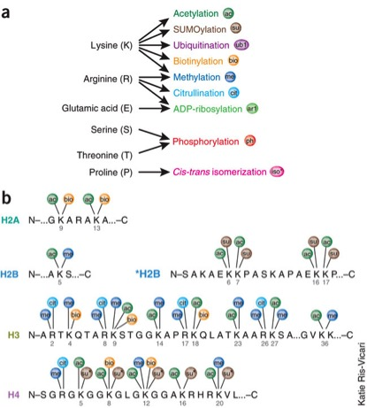

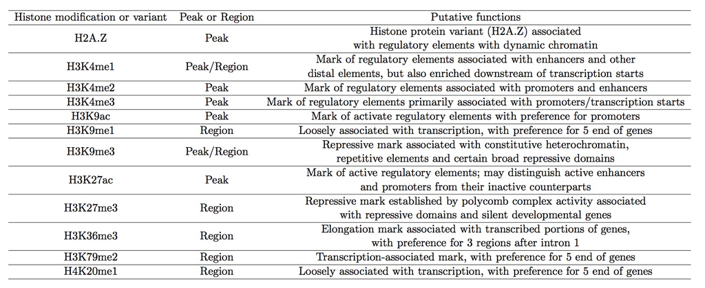

CONGRATULATIONS! You’ve made it to the end of the practical.

Hope you enjoyed it!

Don’t hesitate to ask any questions and feel free to contact us any time (email addresses on the front page).

# Bonus Exercise I: How to check if the ChIP worked

Before to explore any results form ChIP-seq data, it is important to verify if the ChIP worked. In other words, did the antibody-treatment enrich sufficiently so that the ChIP signal can be separated from the background signal? To test this, we are using the ‘plotFingerprint’ function from deepTools (http://deeptools.readthedocs.io/en/latest/content/tools/plotFingerprint.html). This tool plots a profile of cumulative read coverages for the INPUT and ChIP. It is used to determine how well the signal in the ChIP-seq sample can be differentiated from the background distribution of reads in the control sample. Also different type of profiles are expected for ChIPs resulting in narrow or broad regions.

First, you should go back to the correct directory:

```
cd ~/Course_Materials/Practicals/ChIPseq
```

To test if the Oct4 ChIP worked, type:

```
plotFingerprint -b Oct4.sorted.bam Input.sorted.bam -plot Oct4_fingerprint.png
```

## Questions

1. Compare ‘Oct4_fingerprint.png’ with the examples below. Can you conclude if the ChIP worked?

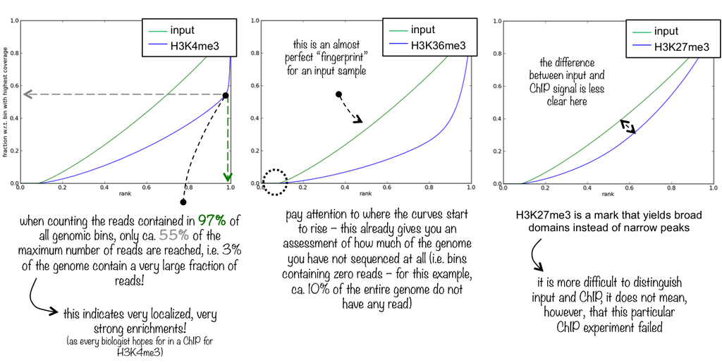

fingerprint_examples

# Bonus Exercise II: How to remove duplicates by Using Picard

Duplicate reads are the ones having the same start and end coordinates. This may be the result of technical duplication (too many PCR cycles), or over-sequencing (very high fold coverage). It is very important to put the duplication level in context of your experiment. For example, duplication level in targeted or re-sequencing projects may mean different than in RNA-seq experiments. In RNA-seq experiments over-sequencing is usually necessary when detecting the low expressed transcripts.

The duplication level computed by **FastQC** is based on sequence identity at the end of reads. Another tool, **Picard**, determines duplicates based on identical start and end positions.

Picard is a suite of tools for performing many common tasks with SAM/BAM format files. For more information see the [Picard website](http://broadinstitute.github.io/picard/) and information about the various command-line tools.

One of the Picard tools (MarkDuplicates) can be used to analyse and remove duplicates from the raw sequence data. The input for Picard is a sorted alignment file in `.bam` format.

To remove duplicates reads for the Input, Type:

```
java -jar /applications/local/picard/picard-2.20.6/picard.jar MarkDuplicates \
    INPUT=Input.sorted.bam \
    VALIDATION_STRINGENCY=LENIENT \
    OUTPUT=Input.sorted.picard.dup  \
    METRICS_FILE=Input.sorted.picard.metric \
    ASSUME_SORTED=true \
    REMOVE_DUPLICATES=true
```

Changing the code, remove duplicates reads for the Oct4 ChIP.

## Questions

1. What is the percentage of duplication for the INPUT and Oct4 ChIP-seq data? You can find this information in ‘Input.sorted.picard.matric’ and ‘Oct4.sorted.picard.matric’ files.

CONGRATULATIONS! You’ve made it to the end of the bonus exercises.

Hope you enjoyed it!

Don’t hesitate to ask any questions and feel free to contact us any time (email addresses on the front page).